# Making Maps in R

This is basic example of how to create maps with ggplot. We’re using some data layers generated by the JournalMap project on article study area locations.

```r
plos_blocks <- readOGR(dsn="C:\\Users\\Jason Karl\\Documents\\GitHub\\REM504-DataScience\\Practice_Datasets", layer="PLOS_re_5deg_blocks",stringsAsFactors = FALSE)
```

### Crappy plots

You can use the basic **plot()** functions to take a quick look at any spatial object in R. These plots aren’t much use for anything else, though.

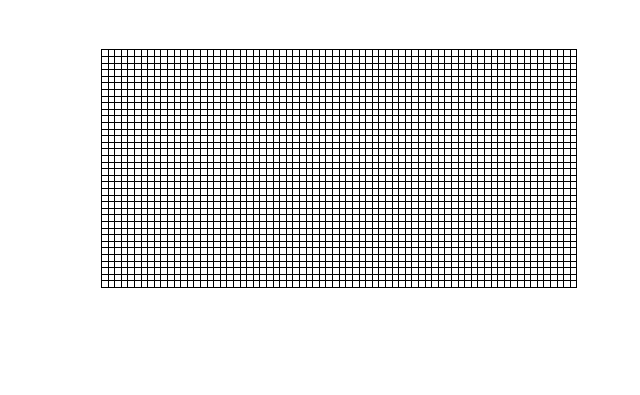

### Building a map with ggplot

You can use ggplot to build maps from spatial objects in R. You just need a couple of extra layers to the ggplot function.

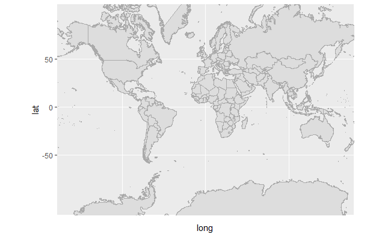

OK. That’s basic, but it’s a start. Let’s apply some styling and clean up the borders

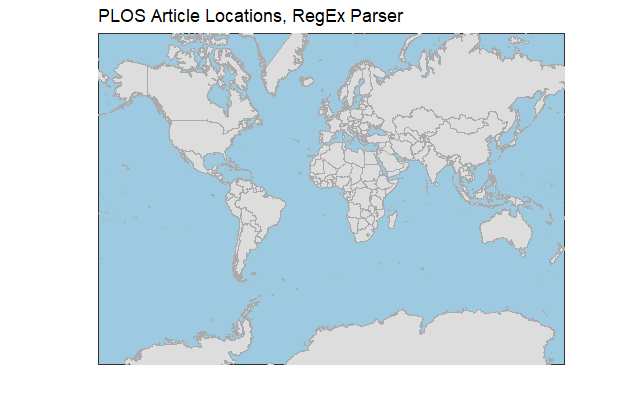

```r
map <- map + labs(x="", y="", title="PLOS Article Locations, RegEx Parser")+
  theme(axis.ticks.y = element_blank(), axis.text.y = element_blank(),
        axis.ticks.x = element_blank(), axis.text.x = element_blank(),
        panel.grid = element_blank(),
        panel.background = element_rect(fill="#9ecae1",color="#333333"))
        #plot.margin = unit(c(0,0,0,0),"points"))
map
```

That’s starting to look pretty close to what we want. Let’s add the 5-degree blocks and color-code them by article count.

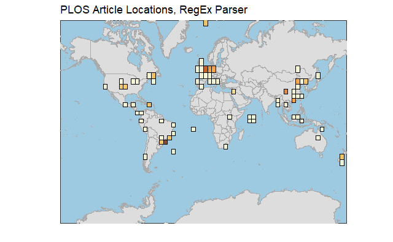

```r
plos_blocks@data$id <- row.names(plos_blocks@data)
block.verts <- fortify(plos_blocks, region="id") # Fortify turns a Spatial Data Frame into a regular data frame. GGPLOT needs regular data frames.
blocks.df <- merge(block.verts, plos_blocks@data, by="id") # Merge the attributes into the new data frame.
blocks.df <- blocks.df[blocks.df$PNT_COUNT>0,] # Screen out empty blocks
map+geom_polygon(data=blocks.df, # Add the polygons
                 aes(x=long,y=lat,group=group,
                     fill=PNT_COUNT),alpha=0.8,
                     color="black",size=0.5)+
    scale_fill_manual(values=c('#ffffd4', # Create the color ramp
                        '#fee391',
                        '#fec44f',
                        '#fe9929',
                        '#ec7014',
                        '#cc4c02',
                        '#8c2d04'),
                      breaks = c(1,3,5,8,21),guide=FALSE) #guides=FALSE turns off the legend.
```

Let’s remake that figure using a google map service as the background. We’ll use the ggmap library for this.

```r
library(ggmap)
map <- get_googlemap(center=c(lat=0,lon=0), zoom=2, size=c(640,500), scale=2) %>% ggmap(extent="device") + coord_map()
```

```
`panel.margin` is deprecated. Please use `panel.spacing` property instead
```

[figure not shown]

```r
map + geom_polygon(data=blocks.df, aes(x=long,y=lat,group=group,fill=PNT_COUNT),alpha=0.8,color="black",size=0.5)+
  scale_fill_manual(values=c('#ffffd4','#fee391','#fec44f','#fe9929','#ec7014','#cc4c02','#8c2d04'), breaks = c(1,3,5,8,21),guide=FALSE)
```

Well, need to play around with the extents, sizing, etc., but you get the idea. ggmap gives access to other map tile services too like Open Streetmap and Stamen Maps. Pretty helpful for if/when you just need to drop some features on top of a generic basemap.

### Dynamic maps with Leaflet

What about if you wanted to have some dynamic/interactive maps? The Leaflet package can do that!

[interactive chart not shown]